# Principle Components Analysis Application for Animal Classification Grouping

Pete Pham

# Table of Contents

# Introduction

This document is a brief description of the application of Principle Components Analysis (PCA) to characterize how different animal populations were behaving near the new construction of the Kinsman road crossing. This project was conducted on the behalf of an unnamed client with the goal of providing in-depth data exploration to gain further insight of the effect of road construction, urbanization, and under-road crossings have on population migration patterns.

In 2018, the city of Wilsonville planned to bifurcate a region of wetland to connect to major thoroughfares to facilitate traffic to the I-205 highway. Before construction, the city hoped to gain insight on how populations were disturbed by the wildlife crossing and how effective under-road animal crossings are in mitigated any perceived effect of the road constructions. The dataset was collected by the client’s staff before and after the road was constructed in hopes of recording any changes.

Motion-activated cameras were placed on several trees that were located near the planned construction of the wildlife crossings. When the road construction was complete, the same cameras were replaced on the same trees to observe any movement through the underground tunnels. Images were then interpreted by staff and results were recorded in tabular form that was received for analysis.

A priority for this analys was to identify with animal populations behaved most similarly and if those same animal groupings remain consistent after the road construction. From there, general analysis on the most active times of day is developed and recommendations proposed.

# Principal Components Analysis

Principal components analysis (PCA) is a technique that is often used for variables reduction/selection. By transforming the data matrix orthogonally, we recreate each variable of interest into a new set of variables that are made up of all of the orginal variables. These new “variables” are principal components and are ordered from most to least variable. This is especially use as we want to find which variables have the most variability. For clarification, any variable that has exceptionally low or non-existent variation does not have any information that may be useful for us. More popularly, this distinction indicates which principle components may be dropped from the analysis to reduce the effects of multi-collinearity. This same conclusion also allows us to infer which groups have large amounts of variables together - or which variables can be grouped together.

Note: I cannot stress how amazing the here package is for importing datasets into R!

```r
# Packages Used
library(readxl)
library(factoextra)
library(FactoMineR)
library(knitr)
library(gridExtra)
library(here)

# Import data and separate into separate pre and post data frames
pre = read_excel(here("Datasets","kinsman", "pca.xlsx"), sheet = "pca.pre.c")
post = read_excel(here("Datasets","kinsman", "pca.xlsx"), sheet = "pca.post.c")
pre = data.frame(pre)
post = data.frame(post)


# Select the first 7 variables (columns) of each dataset
pre.n = pre[1:7]
post.n = post[1:7]
```

We select the first seven variables because those variables are the only continuous variables in the dataset. The other variables contain categorical information and will be applied in the classification process later. With our desired data matrix complete and in data frame form, we can proceed to executing the PCA:

```r
# Perform PCA on data matrix. Scale normalizes the matrix
pca.pre = prcomp(pre.n, scale = TRUE) #PCA for pre-construction data
pca.post = prcomp(post.n, scale = TRUE) #PCA for post0construction data

pca.pre
```

```
## Standard deviations (1, .., p=7):
## [1] 1.4829854 1.1854353 1.0066585 0.9818046 0.7882095 0.7461025 0.4901558
##
## Rotation (n x k) = (7 x 7):
##                PC1         PC2        PC3         PC4         PC5         PC6
## month  -0.08242372  0.66902446 -0.3317045  0.35586389 -0.35532867 -0.02332414
## count   0.17002928  0.05757582  0.8168424  0.45660251 -0.23168457  0.19537038
## hour    0.26323481  0.34663241  0.1439613 -0.72418444 -0.26881973  0.43883430
## pcip   -0.28298721  0.55260339  0.2184996 -0.01663669  0.73761899  0.09225116
## tmax    0.54514998 -0.18834927 -0.1366700  0.13256785  0.44429491  0.32710735
## tmin    0.53813649  0.20961357 -0.3067611  0.29238223  0.01972144  0.14318698
## ntraff  0.47764282  0.21012725  0.2036972 -0.19259685  0.07701343 -0.79542369
##                PC7
## month   0.42678233
## count   0.01450253
## hour    0.02336323
## pcip   -0.11805430
## tmax    0.57156447
## tmin   -0.68263465
## ntraff  0.10241023
```

```r
pca.post
```

```
## Standard deviations (1, .., p=7):
## [1] 1.4513268 1.2061852 0.9881957 0.9501570 0.8733799 0.7768753 0.4394441
##
## Rotation (n x k) = (7 x 7):
##                PC1         PC2         PC3          PC4        PC5         PC6
## month  -0.41019881  0.11104622 -0.24755762  0.267954930 -0.7466246  0.35890306
## count  -0.11265669  0.39210220 -0.80288180 -0.013616881  0.1951593 -0.38798007
## hour..  0.10573086  0.56475342  0.45019761  0.268066505 -0.2927194 -0.55070231
## pcip   -0.28323509  0.29306463  0.13764327 -0.855341049 -0.1323947  0.04921754
## tmax    0.61954218 -0.02042122 -0.22315956  0.001283878 -0.2128502  0.13221463
## tmin    0.58095865  0.12861436 -0.11979408 -0.304885914 -0.3264165  0.07589869
## ntraff  0.07936511  0.64197557  0.09122324  0.177734931  0.3865212  0.62587806
##                 PC7
## month   0.007834217
## count   0.012002949
## hour.. -0.079870743
## pcip   -0.251766373
## tmax   -0.709339639
## tmin    0.652940266
## ntraff  0.023134331
```

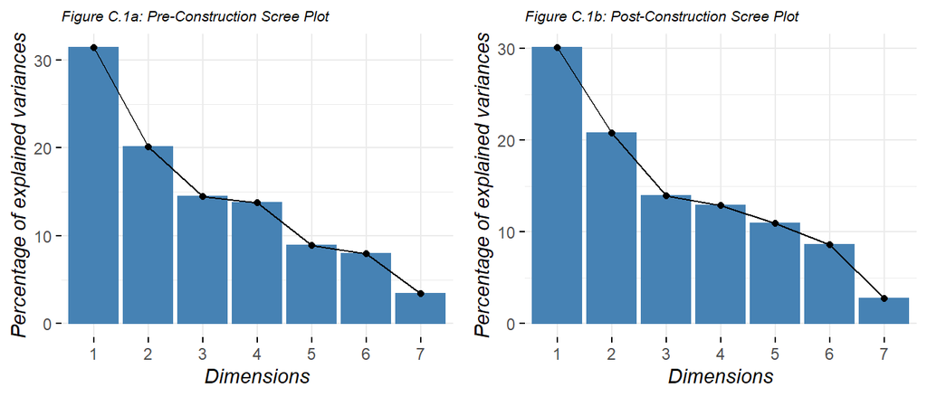

```r
pre.scree = fviz_eig(pca.pre,
                      title = "Figure C.1a: Pre-Construction Scree Plot") + theme(plot.title = element_text(size=8), title = element_text(face = "italic"))

post.scree = fviz_eig(pca.post,
                       title = "Figure C.1b: Post-Construction Scree Plot") + theme(plot.title = element_text(size=8), title = element_text(face = "italic"))

grid.arrange(pre.scree,post.scree, ncol=2)
```

As seen above, the scree plots for both pre and post-construction show many principle dimensions. This is not ideal as we cannot readily visualize 4 or more dimensions. Though we miss a great deal of detail by examining fewer plots, we can still gain a sense of understanding since there is already so much noise in the datasets. The following plots will only be shown in two dimensions for ease of interpretation. For three-dimensional principle components plots, please refer to the R-code at the end of this section.

# Numerical Tables for Plot Generation

With the PCA completed, we now move to extract the results of the analysis and visualize. Numerical tables are created to observe the orthogonal transformation of each variable component into their respective principal components. These tables will provide the raw data for visualizations to be generated. Numerical tables also provide concrete values to be reviewed.

Three types of tables are calculated in order to derive the points for plot generation. These are:

- **Coordinates** - The coordinates of each variable that are used to create a scatter plot. Note, there are seven values for each variable, meaning we can plot them into seven dimensions. For ease of interpretation, we will limit ourselves to just two dimensions.
- **Quality of Represenation** - This is the square of the coordinate of each variable. This number is the sum of square distance of the observation when the original data point is projected onto a component.
- **Contribution** - For each relative principal component, this is a variable’s percent contribution to that specific dimension.

### *PCA Coordinates*

```r
# Extract the eigenvalues of each eigenmatrix from pre/post PCA
pre.eig = get_eigenvalue(pca.pre)
post.eig = get_eigenvalue(pca.post)

# Define variable coordinates of the pre-construction PCA
pre.vcf = function(pre.load, comp.sdev){pre.load*comp.sdev}
pre.load = pca.pre$rotation # extract values from above PCA
pre.sdev = pca.pre$sdev # extract standard deviation from above PCA
pre.vcoord = t(apply(pre.load, 1, pre.vcf, pre.sdev ))
pre.vc = head(pre.vcoord[,1:7])

# Define variable coordinates of the post-construction PCA
post.vcf = function(post.load, comp.sdev){post.load*comp.sdev}
post.load = pca.post$rotation # extract values from above PCA
post.sdev = pca.post$sdev # extract standard deviation from above PCA
post.vcoord = t(apply(post.load, 1, post.vcf, post.sdev))
post.vc = head(post.vcoord[,1:7])

# Format output tables via kable
kable(pre.vc[1:6,1:7], caption = "Pre-Construction Variable Coordinates")
```

Pre-Construction Variable Coordinates

|  | PC1 | PC2 | PC3 | PC4 | PC5 | PC6 | PC7 |
| --- | --- | --- | --- | --- | --- | --- | --- |
| month | -0.1222332 | 0.7930852 | -0.3339131 | 0.3493888 | -0.2800734 | -0.0174022 | 0.2091898 |
| count | 0.2521509 | 0.0682524 | 0.8222814 | 0.4482944 | -0.1826160 | 0.1457663 | 0.0071085 |
| hour | 0.3903734 | 0.4109103 | 0.1449199 | -0.7110076 | -0.2118863 | 0.3274154 | 0.0114516 |
| pcip | -0.4196659 | 0.6550756 | 0.2199545 | -0.0163340 | 0.5813983 | 0.0688288 | -0.0578650 |
| tmax | 0.8084495 | -0.2232759 | -0.1375800 | 0.1301557 | 0.3501975 | 0.2440556 | 0.2801556 |
| tmin | 0.7980485 | 0.2484833 | -0.3088037 | 0.2870622 | 0.0155446 | 0.1068322 | -0.3345973 |

```r
kable(post.vc[1:6,1:7], caption = "Post-Construction Variable Coordinates")
```

Post-Construction Variable Coordinates

|  | PC1 | PC2 | PC3 | PC4 | PC5 | PC6 | PC7 |
| --- | --- | --- | --- | --- | --- | --- | --- |
| month | -0.5953325 | 0.1339423 | -0.2446354 | 0.2545993 | -0.6520869 | 0.2788229 | 0.0034427 |
| count | -0.1635017 | 0.4729479 | -0.7934043 | -0.0129382 | 0.1704482 | -0.3014121 | 0.0052746 |
| hour.. | 0.1534500 | 0.6811972 | 0.4448833 | 0.2547053 | -0.2556553 | -0.4278270 | -0.0350987 |
| pcip | -0.4110667 | 0.3534902 | 0.1360185 | -0.8127083 | -0.1156309 | 0.0382359 | -0.1106373 |
| tmax | 0.8991581 | -0.0246318 | -0.2205253 | 0.0012199 | -0.1858991 | 0.1027143 | -0.3117152 |
| tmin | 0.8431608 | 0.1551327 | -0.1183800 | -0.2896895 | -0.2850856 | 0.0589638 | 0.2869308 |

# Numerical Tables for Plot Generation (Continued)

### *Variable Quality of Representation*

```r
pre.cos2 = pre.vcoord^2
post.cos2 = post.vcoord^2
kable(pre.cos2[1:6,1:7], caption = "Pre-Construction Variable Quality of Representation")
```

Pre-Construction Variable Quality of Representation

|  | PC1 | PC2 | PC3 | PC4 | PC5 | PC6 | PC7 |
| --- | --- | --- | --- | --- | --- | --- | --- |
| month | 0.0149409 | 0.6289842 | 0.1114980 | 0.1220725 | 0.0784411 | 0.0003028 | 0.0437604 |
| count | 0.0635801 | 0.0046584 | 0.6761467 | 0.2009679 | 0.0333486 | 0.0212478 | 0.0000505 |
| hour | 0.1523914 | 0.1688473 | 0.0210018 | 0.5055318 | 0.0448958 | 0.1072008 | 0.0001311 |
| pcip | 0.1761195 | 0.4291240 | 0.0483800 | 0.0002668 | 0.3380240 | 0.0047374 | 0.0033484 |
| tmax | 0.6535905 | 0.0498521 | 0.0189283 | 0.0169405 | 0.1226383 | 0.0595631 | 0.0784872 |
| tmin | 0.6368815 | 0.0617440 | 0.0953597 | 0.0824047 | 0.0002416 | 0.0114131 | 0.1119554 |

```r
kable(post.cos2[1:6,1:7], caption = "Post-Construction Variable Quality of Representation")
```

Post-Construction Variable Quality of Representation

|  | PC1 | PC2 | PC3 | PC4 | PC5 | PC6 | PC7 |
| --- | --- | --- | --- | --- | --- | --- | --- |
| month | 0.3544208 | 0.0179405 | 0.0598465 | 0.0648208 | 0.4252174 | 0.0777422 | 0.0000119 |
| count | 0.0267328 | 0.2236797 | 0.6294905 | 0.0001674 | 0.0290526 | 0.0908493 | 0.0000278 |
| hour.. | 0.0235469 | 0.4640296 | 0.1979212 | 0.0648748 | 0.0653596 | 0.1830359 | 0.0012319 |
| pcip | 0.1689758 | 0.1249553 | 0.0185010 | 0.6604948 | 0.0133705 | 0.0014620 | 0.0122406 |
| tmax | 0.8084853 | 0.0006067 | 0.0486314 | 0.0000015 | 0.0345585 | 0.0105502 | 0.0971663 |
| tmin | 0.7109202 | 0.0240662 | 0.0140138 | 0.0839200 | 0.0812738 | 0.0034767 | 0.0823293 |

### *Variable Contribution*

```r
pre.cc2 = apply(pre.cos2, 2, sum)
contrib = function(pre.cos2, pre.cc2){pre.cos2*100/pre.cc2}
pre.varc = t(apply(pre.cos2, 1, contrib, pre.cc2))
pre.vcontrib = head(pre.varc[,1:7])
post.cc2 = apply(post.cos2, 2, sum)
contrib = function(post.cos2, post.cc2){post.cos2*100/post.cc2}
post.varc = t(apply(post.cos2, 1, contrib, post.cc2))
post.vcontrib = head(post.varc[,1:7])
kable(pre.vcontrib[1:6,1:7], caption = "Pre-Construction Variable Dimension Contribution (%)")
```

Pre-Construction Variable Dimension Contribution (%)

|  | PC1 | PC2 | PC3 | PC4 | PC5 | PC6 | PC7 |
| --- | --- | --- | --- | --- | --- | --- | --- |
| month | 0.6793669 | 44.7593734 | 11.002785 | 12.663911 | 12.6258465 | 0.0544015 | 18.2143155 |
| count | 2.8909955 | 0.3314975 | 66.723157 | 20.848585 | 5.3677741 | 3.8169585 | 0.0210323 |
| hour | 6.9292564 | 12.0154029 | 2.072487 | 52.444311 | 7.2264046 | 19.2575547 | 0.0545841 |
| pcip | 8.0081760 | 30.5370504 | 4.774208 | 0.027678 | 54.4081782 | 0.8510277 | 1.3936819 |
| tmax | 29.7188505 | 3.5475448 | 1.867869 | 1.757424 | 19.7397963 | 10.6999218 | 32.6685943 |
| tmin | 28.9590880 | 4.3937848 | 9.410239 | 8.548737 | 0.0388935 | 2.0502512 | 46.5990066 |

```r
kable(post.vcontrib[1:6,1:7], caption = "Post-Construction Variable Dimension Contribution (%)")
```

Post-Construction Variable Dimension Contribution (%)

|  | PC1 | PC2 | PC3 | PC4 | PC5 | PC6 | PC7 |
| --- | --- | --- | --- | --- | --- | --- | --- |
| month | 16.826306 | 1.2331263 | 6.128477 | 7.1799845 | 55.744827 | 12.8811410 | 0.0061375 |
| count | 1.269153 | 15.3744133 | 64.461918 | 0.0185419 | 3.808714 | 15.0528534 | 0.0144071 |
| hour.. | 1.117902 | 31.8946421 | 20.267789 | 7.1859651 | 8.568466 | 30.3273030 | 0.6379336 |
| pcip | 8.022211 | 8.5886875 | 1.894567 | 73.1608310 | 1.752836 | 0.2422366 | 6.3386307 |
| tmax | 38.383251 | 0.0417026 | 4.980019 | 0.0001648 | 4.530520 | 1.7480709 | 50.3162724 |
| tmin | 33.751295 | 1.6541654 | 1.435062 | 9.2955420 | 10.654775 | 0.5760611 | 42.6330991 |

# Individual Plots

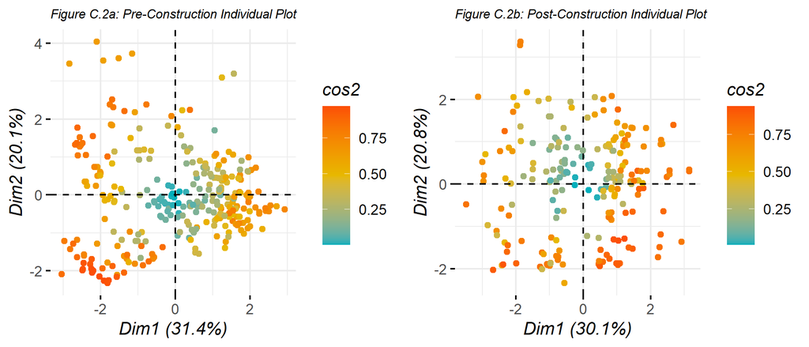

```r
pre.ind = fviz_pca_ind(pca.pre,
                        col.ind = "cos2",
                        gradient.cols = c("#00AFBB", "#E7B800", "#FC4E07"),   #default R colors
                        repel = TRUE,
                        label = "none",
                        title = "Figure C.2a: Pre-Construction Individual Plot") + theme(plot.title = element_text(size=8), title = element_text(face = "italic"))

post.ind = fviz_pca_ind(pca.post,
                        col.ind = "cos2",
                        gradient.cols = c("#00AFBB", "#E7B800", "#FC4E07"),   #default R colors
                        repel = TRUE,
                        label = "none",
                        title = "Figure C.2b: Post-Construction Individual Plot") + theme(plot.title = element_text(size=8), title = element_text(face = "italic"))

grid.arrange(pre.ind,post.ind, ncol=2)
```

# Variable Plots

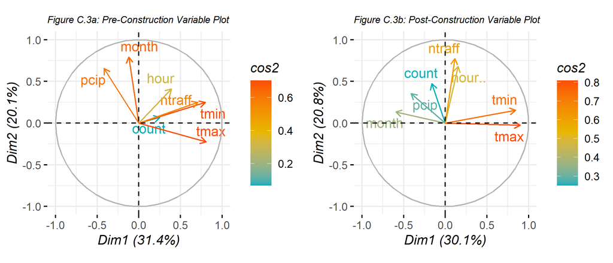

```r
pre.var = fviz_pca_var(pca.pre,
                        col.var = "cos2",
                        gradient.cols = c("#00AFBB", "#E7B800", "#FC4E07"),   #default R colors
                        repel = TRUE,
                        title = "Figure C.3a: Pre-Construction Variable Plot") + theme(plot.title = element_text(size=8), title = element_text(face = "italic"))

post.var = fviz_pca_var(pca.post,
                         col.var = "cos2",
                         gradient.cols = c("#00AFBB", "#E7B800", "#FC4E07"),   #default R colors
                         repel = TRUE,
                         title = "Figure C.3b: Post-Construction Variable Plot") + theme(plot.title = element_text(size=8), title = element_text(face = "italic"))

grid.arrange(pre.var,post.var, ncol=2)
```

Similar to the individual contribution plots above, these variable plots measure only the contribution that each collected variable provides relative to each other. Arrows that point away from each other indicate non-correlated data. Arrows that point in the same direction indicate more correlated data.

In this particular case, we note that precipitation and month are closely correlated. This makes sense give that precipitation amounts are often seasonal and go hand-in-hand with months. Additionally, we see strong correlation between daily minimum and maximum temperature. This is not surprising as we expect to see fairly consistent differences between daily highs and lows. Traffic appears to correlated with hour in both plots, again, this is to be expected.

# Biplots

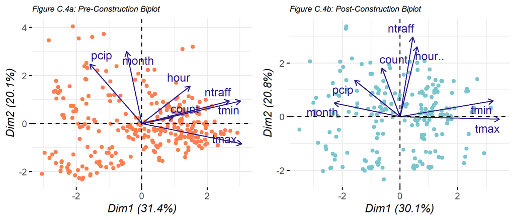

```r
pre.bp = fviz_pca_biplot(pca.pre,
                         col.ind = "coral",
                         col.var = "#2f2091",
                         label = "var",
                         repel = TRUE,
                         title = "Figure C.4a: Pre-Construction Biplot") + theme(plot.title = element_text(size=8), title = element_text(face = "italic"))


post.bp = fviz_pca_biplot(pca.post,
                           col.ind = "cadetblue3",
                           col.var = "#2f2091",
                           label = "var",
                           repel = TRUE,
                           title = "Figure C.4b: Post-Construction Biplot") + theme(plot.title = element_text(size=8), title = element_text(face = "italic"))

grid.arrange(pre.bp,post.bp, ncol=2)
```

These two biplots overlay variable contributions on top of the indivudal observations into a singular plot. This provides a succinct method to quickly evaluate how each observation corresponds with each variable.

# Individual Plots with Overlaid Categorical Ellipses

The following plots show the relative grouping the several categorical variables onto the individual principle components plot. Each plot will have an ellipses generated on top of a pre or post-construction individiual pca plot. Each generated ellipse has a center that is the mean of all relative points.

Each page will have pre-construction and post-construction plots adjacent to each other. Please note that due to variation in sampling methodology, any changes due to the road construction cannot be reliably determined. In that light, they can serve to highlight how the activity of the populations in the two datasets behave.

The categorical plots are generated in this order:

```r
pre.g.species = as.factor(pre$species[1:349])
pre.g.cat = as.factor(pre$category[1:349])
pre.g.dnc = as.factor(pre$dnc[1:349])
pre.g.cam = as.factor(pre$camera[1:349])
pre.g.traffic = as.factor(pre$traffic[1:349])


post.g.species = as.factor(post$species[1:222])
post.g.cat = as.factor(post$category[1:222])
post.g.dnc = as.factor(post$dnc[1:222])
post.g.cam = as.factor(post$camera[1:222])
post.g.traffic = as.factor(post$traffic[1:222])
```

## *Categorical Plots: Species*

The plots, below, show how each species interacts with each other. This could provide a useful framework to approach future culvert design to better improve usability for specific groups instead of specific species. Generally speaking, we can see that deer and coyote form two of the larger, more distinct groups. Additionally, we see that deer mice and coyote are simiarly grouped. This specific interaction could suggest a predator-prey relationship as well as culvert preference due to their smaller size.

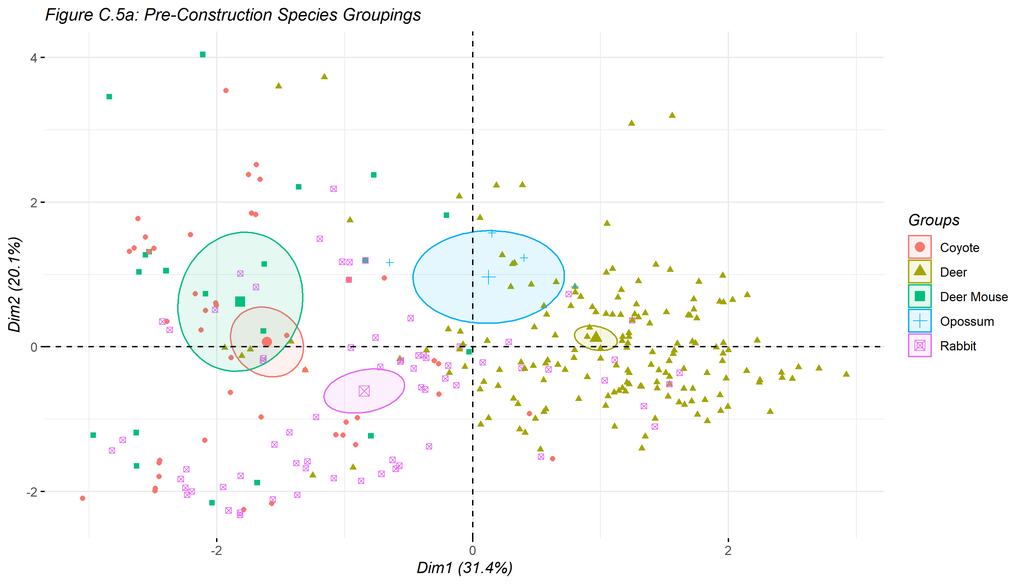

```r
pre.species = fviz_pca_ind(pca.pre,
                            col.ind = pre.g.species,
                            palette = c( ),
                            addEllipses = TRUE,
                            ellipse.type = "confidence",
                            legend.title = "Groups",
                            repel = TRUE,
                            label = "none",
                            title = "Figure C.5a: Pre-Construction Species Groupings") + theme(plot.title = element_text(size=12), title = element_text(face = "italic"))

post.species = fviz_pca_ind(pca.post,
                            col.ind = post.g.species,
                            palette = c( ),
                            addEllipses = TRUE,
                            ellipse.type = "confidence",
                            legend.title = "Groups",
                            repel = TRUE,
                            label = "none",
                            title = "Figure C.5b: Post-Construction Species Groupings") + theme(plot.title = element_text(size=12), title = element_text(face = "italic"))

pre.species
```

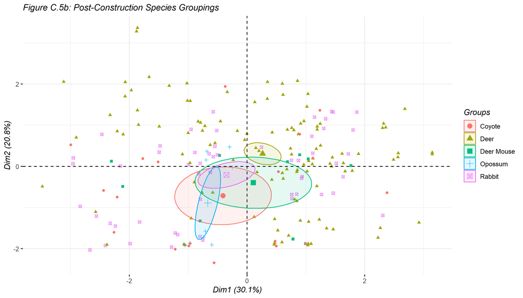

```r
post.species
```

## *Categorical Plots: Mammalian Groups*

Simiar to the species plots above, we broaden our scope of definition and sort our species counts by mammalian groups. Each species observation is still noted, but the colors here refer to the key seen on the right-hand side of the plots. Pre-construction shows a clear grouping of deer while every other mammalian group are more similar to each other. In post-construction, we see the variations between the groups are more clustered together. This could indicate that the culverts presents a funneling effect.

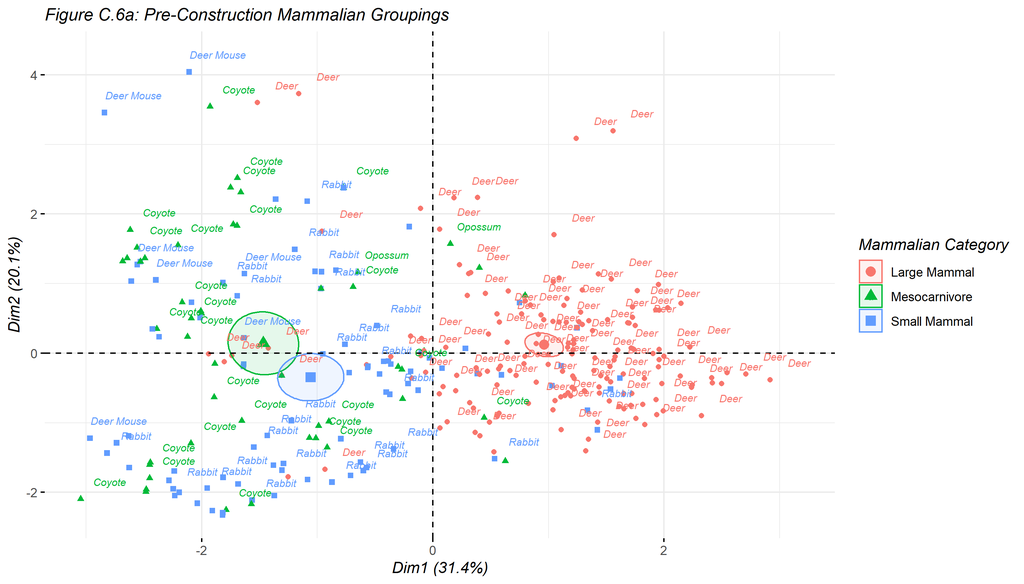

```r
pre.cat = fviz_pca_ind(pca.pre,
                            col.ind = pre.g.cat,
                            palette = c( ),
                            addEllipses = TRUE,
                            ellipse.type = "confidence",
                            legend.title = "Mammalian Category",
                            repel = TRUE,
                            label = "none",
                            title = "Figure C.6a: Pre-Construction Mammalian Groupings") +
                   geom_text(aes(fontface=3, color = pre$category),
                            label = pre$species,
                            nudge_x = 0.25, nudge_y = 0.25,
                            check_overlap = T,
                            size = 2.5) + theme(plot.title = element_text(size=12), title = element_text(face = "italic"))

post.cat = fviz_pca_ind(pca.post,
                        col.ind = post.g.cat,
                        palette = c( ),
                        addEllipses = TRUE,
                        ellipse.type = "confidence",
                        legend.title = "Groups",
                        repel = TRUE,
                        label = "none",
                        title = "Figure C.6b: Post-Construction Mammalian Groupings") +
               geom_text(aes(fontface=3, color = factor(post$category)),
                        label=post$species,
                        nudge_x = 0.25, nudge_y = 0.25,
                        check_overlap = T,
                        size = 2.5) + theme(plot.title = element_text(size=12), title = element_text(face = "italic"))


pre.cat
```

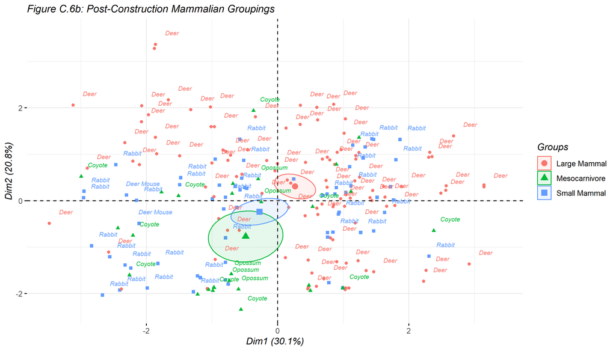

```r
post.cat
```

## *Categorical Plots: Diel Activity Groups*

Here, we can further our scope from mammalian groups into specific hourly activity preference that species are known for. There are two groups - crepuscular and nocturnal. Crepuscular animals are more active during the dawn and evening hours while nocturnal animals are more active during night time hours. In pre-construction, we see the two categories are distinctly grouped - as is expected. These groupings still exist in post-construction, yet the variability is more evenly mixed and centered. If these two groups are merging, then it could further suppport the notion that the culverts present a funneling effect.

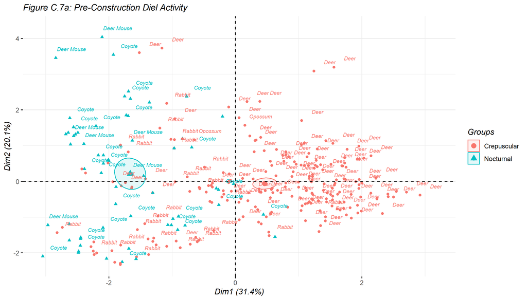

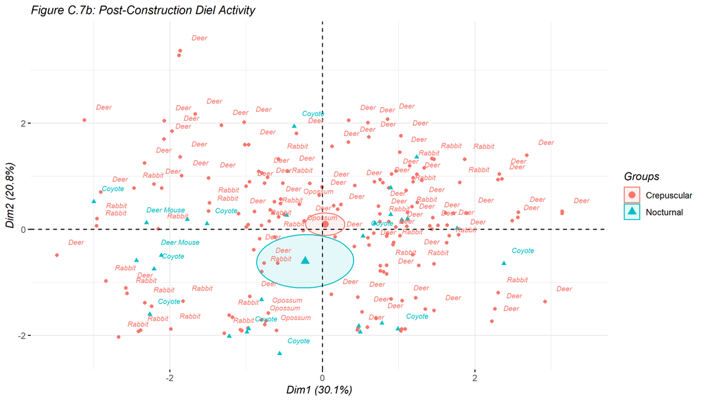

## *Categorical Plots: Camera Preference*

When examining the general groupings for camera preference, we notice some intrigueing changes in behavior. In pre-construction observations, there are two distinct groupings. The first grouping involves camera camera *2 North* and *4 South* while the second group involves camera *1 North* and camera *3 South*. In pre-construction, this particular grouping is likely due to the angle of the cameras. In post-construction, however, all of the cameras seem to have more overlap. This could suppor the notion that the culverts present a funneling effect.

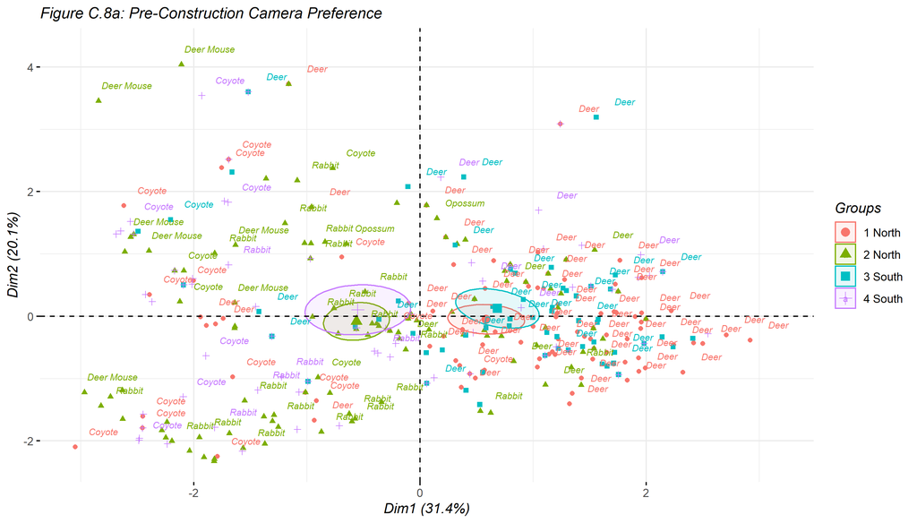

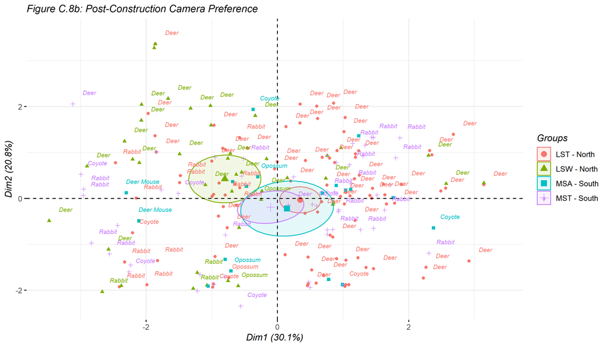

## *Categorical Plots: Traffic*

When overlaid with recent traffic data onto our historical data, we can see some relationship with the presence of traffic.Only post-construction data can be examined here due to the lack of a constructed roadway in pre-construction settings. In post-construction, it’s observed that coyotes have a preference for traffic while every other species does not seem affected. This could present an issue with coyote’s natural hunting patterns as traffic is presenting as a barrier to prey access.

It should strongly noted that the datasets used for the traffic analysis are severely mismatched. The observational data sets are from the year 2015-2016 and 2018-2019 while the traffic data is from 2020 and in a location that is due approximately 300 meters due north at Boeckman Road. It could be assumed that populations that access the Boeckman Road and Kinsman Road crossings are the same populations. However, there is no empirical basis for this assumption.

The results here should only be used to encourage the need for additional study with improved sampling methods.

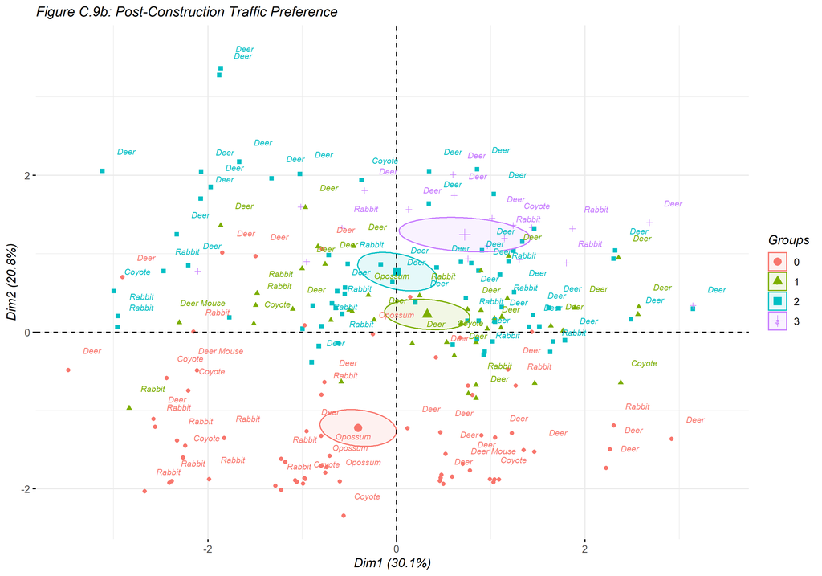

# R Code (1 of 8)

```r
# Import data set from github
# Github Access URL: https://github.com/Kinsman-Road/rcode.git
library(readxl)
pre = read_excel("PCA/pca.xlsx", sheet = "pca.pre.c")
post = read_excel("PCA/pca.xlsx", sheet = "pca.post.c")

# Prepare dataframes
pre = data.frame(pre)
post = data.frame(post)

pre.n = pre[1:7]      #create dataframes with only numerical columns from pre
post.n = post[1:7]    #create dataframes with only numerical columns from post

# Performing principal components analysis
library(factoextra)
library(FactoMineR)

pca.pre = prcomp(pre.n, scale = TRUE)   #singular value decomposition
pca.post = prcomp(post.n, scale = TRUE)   #singular value decomposition
pre.eig = get_eigenvalue(pca.pre)
post.eig = get_eigenvalue(pca.post)

# Calculate PCA coordinates

# Pre-Construction PCA Coordinates
pre.vcf = function(pre.load, comp.sdev){pre.load*comp.sdev}
pre.load = pca.pre$rotation
pre.sdev = pca.pre$sdev
pre.vcoord = t(apply(pre.load, 1, pre.vcf, pre.sdev ))
pre.vc = head(pre.vcoord[,1:7])   #1:7 number of dimensions

# Post-Construction PCA Coordinates
post.vcf = function(post.load, comp.sdev){post.load*comp.sdev}
post.load = pca.post$rotation
post.sdev = pca.post$sdev
post.vcoord = t(apply(post.load, 1, post.vcf, post.sdev))
post.vc = head(post.vcoord[,1:7])   #1:7 number of dimensions

pre.vc       #table of pre pca coords
post.vc      #table of post pca coords

# PCA Qualtity of Representation
pre.cos2 = pre.vcoord^2
post.cos2 = post.vcoord^2

pre.cos2     #table of contribution to each dimension
post.cos2    #table of contribution to each dimension
```

# R Code (2 of 8)

```r
# PCA Contributions to Each Given Component
pre.cc2 = apply(pre.cos2, 2, sum)
contrib = function(pre.cos2, pre.cc2){pre.cos2*100/pre.cc2}
pre.varc = t(apply(pre.cos2, 1, contrib, pre.cc2))
pre.vcontrib = head(pre.varc[,1:7])   #1:7 number of dimensions

post.cc2 = apply(post.cos2, 2, sum)
contrib = function(post.cos2, post.cc2){post.cos2*100/post.cc2}
post.varc = t(apply(post.cos2, 1, contrib, post.cc2))
post.vcontrib = head(post.varc[,1:7])   #1:7 number of dimensions

pre.vcontrib
post.vcontrib

# Creating a scree plot to determine principal dimensions of interest
pre.scree = fviz_eig(pca.pre,
                      title = "Pre-Construction Scree Plot")

post.scree = fviz_eig(pca.post,
                       title = "Post-Construction Scree Plot")
pre.scree
post.scree

# Creating contribution plot for individual observations
pre.ind = fviz_pca_ind(pca.pre,
                        col.ind = "cos2",
                        gradient.cols = c("#00AFBB", "#E7B800", "#FC4E07"),
                        repel = TRUE,
                        label = "none",
                        title = "Pre-Construction Individual Plot")

post.ind = fviz_pca_ind(pca.post,
                        col.ind = "cos2",
                        gradient.cols = c("#00AFBB", "#E7B800", "#FC4E07"),
                        repel = TRUE,
                        label = "none",
                        title = "Post-Construction Individual Plot")
pre.ind
post.ind
```

# R Code (3 of 8)

```r
# Creating contribution plot for variable contributions
pre.var = fviz_pca_var(pca.pre,
                        col.var = "cos2",
                        gradient.cols = c("#00AFBB", "#E7B800", "#FC4E07"),
                        repel = TRUE,
                        title = "Pre-Construction Variable Plot")

post.var = fviz_pca_var(pca.post,
                         col.var = "cos2",
                         gradient.cols = c("#00AFBB", "#E7B800", "#FC4E07"),
                         repel = TRUE,
                         title = "Post-Construction Variable Plot")
pre.var
post.var

# Creating a biplot(combination of ind + var plots)
pre.bp = fviz_pca_biplot(pca.pre,
                         col.ind = "coral",
                         col.var = "#2f2091",
                         label = "var",
                         repel = TRUE,
                         title = "Pre-Construction Biplot")

post.bp = fviz_pca_biplot(pca.post,
                           col.ind = "cadetblue3",
                           col.var = "#2f2091",
                           label = "var",
                           repel = TRUE,
                           title = "Post-Construction Biplot")
pre.bp
post.bp

# Creating 3D Observation Plots
library(pca3d)

pre3d.species = pca3d(pca.pre, group=pre$species)
pre3d.mcat = pca3d(pca.pre, group=pre$category)
pre3d.dnc = pca3d(pca.pre, group=pre$dnc)
pre3d.traffic = pca3d(pca.pre, group=pre$traffic)

post3d.species = pca3d(pca.post, group=post$species)
post3d.mcat = pca3d(pca.post, group=post$category)
post3d.dnc = pca3d(pca.post, group=post$dnc)
post3d.traffic = pca3d(pca.post, group=post$traffic)
```

# R Code (4 of 8)

```r
# Creating an individual PCA plot with ellipses for categories
# (1) First define categories as factors

# (1a) Pre categories
pre.g.species = as.factor(pre$species[1:351])
pre.g.solar = as.factor(pre$solar[1:351])
pre.g.cat = as.factor(pre$category[1:351])
pre.g.cam = as.factor(pre$camera[1:351])
pre.g.traffic = as.factor(pre$traffic[1:351])
pre.g.dnc = as.factor(pre$dnc[1:351])

# (1b) Post categories
post.g.species = as.factor(post$species[1:221])
post.g.solar = as.factor(post$solar[1:221])
post.g.cat = as.factor(post$category[1:221])
post.g.cam = as.factor(post$camera[1:221])
post.g.traffic = as.factor(post$traffic[1:221])
post.g.dnc = as.factor(post$dnc[1:221])

# (2) Produce ellipses PCA graphs for every factor

# (2a) Pre-Construction Ellipses PCA categories
pre.species = fviz_pca_ind(pca.pre,
                            col.ind = pre.g.species,
                            palette = c( ),
                            addEllipses = TRUE,
                            ellipse.type = "confidence",
                            legend.title = "Groups",
                            repel = TRUE,
                            label = "none",
                            title = "Pre-Construction: Species Groupings") +
                   geom_text(
                            label=pre$species,
                            nudge_x = 0.25, nudge_y = 0.25,
                            check_overlap = T)

pre.solar = fviz_pca_ind(pca.pre,
                            col.ind = pre.g.solar,
                            palette = c( ),
                            addEllipses = TRUE,
                            ellipse.type = "confidence",
                            legend.title = "Groups",
                            repel = TRUE,
                            label = "none",
                            title = "Pre-Construction: Daylight Preference") +
                   geom_text(
                            label=pre$species,
                            nudge_x = 0.25, nudge_y = 0.25,
                            check_overlap = T)
```

# R Code (5 of 8)

```r
# (2a) Pre-Construction Ellipses PCA categories (Continued)
pre.cat = fviz_pca_ind(pca.pre,
                            col.ind = pre.g.cat,
                            palette = c( ),
                            addEllipses = TRUE,
                            ellipse.type = "confidence",
                            legend.title = "Groups",
                            repel = TRUE,
                            label = "none",
                            title = "Pre-Construction: Mammalian Groupings") +
                   geom_text(
                            label=pre$species,
                            nudge_x = 0.25, nudge_y = 0.25,
                            check_overlap = T)

pre.cam = fviz_pca_ind(pca.pre,
                            col.ind = pre.g.cam,
                            palette = c( ),
                            addEllipses = TRUE,
                            ellipse.type = "confidence",
                            legend.title = "Groups",
                            repel = TRUE,
                            label = "none",
                            title = "Pre-Construction: Camera Preference") +
                   geom_text(
                            label=pre$species,
                            nudge_x = 0.25, nudge_y = 0.25,
                            check_overlap = T)

pre.traffic = fviz_pca_ind(pca.pre,
                           col.ind = pre.g.traffic,
                           palette = c( ),
                           addEllipses = TRUE,
                           ellipse.type = "confidence",
                           legend.title = "Groups",
                           repel = TRUE,
                           label = "none",
                           title = "Pre-Construction: Traffic Preference") +
                  geom_text(
                           label=pre$species,
                           nudge_x = 0.25, nudge_y = 0.25,
                           check_overlap = T)
```

# R Code (6 of 8)

```r
# (2a) Pre-Construction Ellipses PCA categories (Continued)
pre.dnc = fviz_pca_ind(pca.pre,
                            col.ind = pre.g.dnc,
                            palette = c(""),
                            addEllipses = TRUE,
                            ellipse.type = "confidence",
                            legend.title = "groups",
                            repel = TRUE,
                            label = "none",
                            title = "Pre-Construction: D/N/C Category") +
                   geom_text(
                            label=pre$species,
                            nudge_x = 0.25, nudge_y = 0.25,
                            check_overlap = T)

# (2b) Post-Construction Ellipses PCA categories
post.species = fviz_pca_ind(pca.post,
                            col.ind = post.g.species,
                            palette = c( ),
                            addEllipses = TRUE,
                            ellipse.type = "confidence",
                            legend.title = "Groups",
                            repel = TRUE,
                            label = "none",
                            title = "Post-Construction: Species Groupings") +
                   geom_text(
                            label=post$species,
                            nudge_x = 0.25, nudge_y = 0.25,
                            check_overlap = T)

post.solar = fviz_pca_ind(pca.post,
                          col.ind = post.g.solar,
                          palette = c( ),
                          addEllipses = TRUE,
                          ellipse.type = "confidence",
                          legend.title = "Groups",
                          repel = TRUE,
                          label = "none",
                          title = "Post-Construction: Daylight preference") +
                 geom_text(
                          label=post$species,
                          nudge_x = 0.25, nudge_y = 0.25,
                          check_overlap = T)
```

# R Code (7 of 8)

```r
# (2b) Post-Construction Ellipses PCA categories (Continued)
post.cat = fviz_pca_ind(pca.post,
                        col.ind = post.g.cat,
                        palette = c( ),
                        addEllipses = TRUE,
                        ellipse.type = "confidence",
                        legend.title = "Groups",
                        repel = TRUE,
                        label = "none",
                        title = "Post-Construction: Mammalian Groupings") +
               geom_text(
                        label=post$species,
                        nudge_x = 0.25, nudge_y = 0.25,
                        check_overlap = T)

post.cam = fviz_pca_ind(pca.post,
                        col.ind = post.g.cam,
                        palette = c( ),
                        addEllipses = TRUE,
                        ellipse.type = "confidence",
                        legend.title = "Groups",
                        repel = TRUE,
                        label = "none",
                        title = "Post-Construction: Camera Preference") +
               geom_text(
                        label=post$species,
                        nudge_x = 0.25, nudge_y = 0.25,
                        check_overlap = T)

post.traffic = fviz_pca_ind(pca.post,
                            col.ind = post.g.traffic,
                            palette = c( ),
                            addEllipses = TRUE,
                            ellipse.type = "confidence",
                            legend.title = "Groups",
                            repel = TRUE,
                            label = "none",
                            title = "Post-Construction: Traffic Preference") +
                   geom_text(
                            label=post$species,
                            nudge_x = 0.25, nudge_y = 0.25,
                            check_overlap = T)
```

# R Code (8 of 8)

```r
# (2b) Post-Construction Ellipses PCA categories (Continued)
post.dnc = fviz_pca_ind(pca.post,
                             col.ind = post.g.dnc,
                             palette = c( ),
                             addEllipses = TRUE,
                             ellipse.type = "confidence",
                             legend.title = "Groups",
                             repel = TRUE,
                             label = "none",
                             title = "Post-Construction: D/N/C Category") +
                    geom_text(
                             label=post$species,
                             nudge_x = 0.25, nudge_y = 0.25,
                             check_overlap = T)

# Generate Plots
pre.scree
pre.ind
pre.var
pre.bp
pre.species
pre.solar
pre.cat
pre.cam
pre.traffic
pre.dnc

post.scree
post.ind
post.var
post.bp
post.species
post.solar
post.cat
post.cam
post.traffic
post.dnc
```